# 162602_houseprice

Data visualization - EDA Houseprice - ex.1 - Adam Trentowski, 162602

```python
import numpy as np
import pandas as pd
import matplotlib.pyplot as plt
%matplotlib inline
import seaborn as sns
```

```python
df = pd.read_csv('D:/Projekty/DataVisualization/lab_01/files/houseprice.csv')
```

```python
df.head()
```

|  | Id | MSSubClass | MSZoning | LotFrontage | LotArea | Street | Alley | LotShape | LandContour | Utilities | ... | PoolArea | PoolQC | Fence | MiscFeature | MiscVal | MoSold | YrSold | SaleType | SaleCondition | SalePrice |
| --- | --- | --- | --- | --- | --- | --- | --- | --- | --- | --- | --- | --- | --- | --- | --- | --- | --- | --- | --- | --- | --- |
| 0 | 1 | 60 | RL | 65.0 | 8450 | Pave | NaN | Reg | Lvl | AllPub | ... | 0 | NaN | NaN | NaN | 0 | 2 | 2008 | WD | Normal | 208500 |
| 1 | 2 | 20 | RL | 80.0 | 9600 | Pave | NaN | Reg | Lvl | AllPub | ... | 0 | NaN | NaN | NaN | 0 | 5 | 2007 | WD | Normal | 181500 |
| 2 | 3 | 60 | RL | 68.0 | 11250 | Pave | NaN | IR1 | Lvl | AllPub | ... | 0 | NaN | NaN | NaN | 0 | 9 | 2008 | WD | Normal | 223500 |
| 3 | 4 | 70 | RL | 60.0 | 9550 | Pave | NaN | IR1 | Lvl | AllPub | ... | 0 | NaN | NaN | NaN | 0 | 2 | 2006 | WD | Abnorml | 140000 |
| 4 | 5 | 60 | RL | 84.0 | 14260 | Pave | NaN | IR1 | Lvl | AllPub | ... | 0 | NaN | NaN | NaN | 0 | 12 | 2008 | WD | Normal | 250000 |

5 rows × 81 columns

```python
df.tail()
```

|  | Id | MSSubClass | MSZoning | LotFrontage | LotArea | Street | Alley | LotShape | LandContour | Utilities | ... | PoolArea | PoolQC | Fence | MiscFeature | MiscVal | MoSold | YrSold | SaleType | SaleCondition | SalePrice |
| --- | --- | --- | --- | --- | --- | --- | --- | --- | --- | --- | --- | --- | --- | --- | --- | --- | --- | --- | --- | --- | --- |
| 1455 | 1456 | 60 | RL | 62.0 | 7917 | Pave | NaN | Reg | Lvl | AllPub | ... | 0 | NaN | NaN | NaN | 0 | 8 | 2007 | WD | Normal | 175000 |
| 1456 | 1457 | 20 | RL | 85.0 | 13175 | Pave | NaN | Reg | Lvl | AllPub | ... | 0 | NaN | MnPrv | NaN | 0 | 2 | 2010 | WD | Normal | 210000 |
| 1457 | 1458 | 70 | RL | 66.0 | 9042 | Pave | NaN | Reg | Lvl | AllPub | ... | 0 | NaN | GdPrv | Shed | 2500 | 5 | 2010 | WD | Normal | 266500 |
| 1458 | 1459 | 20 | RL | 68.0 | 9717 | Pave | NaN | Reg | Lvl | AllPub | ... | 0 | NaN | NaN | NaN | 0 | 4 | 2010 | WD | Normal | 142125 |
| 1459 | 1460 | 20 | RL | 75.0 | 9937 | Pave | NaN | Reg | Lvl | AllPub | ... | 0 | NaN | NaN | NaN | 0 | 6 | 2008 | WD | Normal | 147500 |

5 rows × 81 columns

```python
df.shape
```

```
(1460, 81)
```

```python
df.shape[0]
```

```
1460
```

```python
df.shape[1]
```

```
81
```

```python
df.dtypes
```

```
Id                 int64
MSSubClass         int64
MSZoning          object
LotFrontage      float64
LotArea            int64
                  ...
MoSold             int64
YrSold             int64
SaleType          object
SaleCondition     object
SalePrice          int64
Length: 81, dtype: object
```

```python
df.info(verbose=True)
```

```
<class 'pandas.core.frame.DataFrame'>
RangeIndex: 1460 entries, 0 to 1459
Data columns (total 81 columns):
 #   Column         Non-Null Count  Dtype
---  ------         --------------  -----
 0   Id             1460 non-null   int64
 1   MSSubClass     1460 non-null   int64
 2   MSZoning       1460 non-null   object
 3   LotFrontage    1201 non-null   float64
 4   LotArea        1460 non-null   int64
 5   Street         1460 non-null   object
 6   Alley          91 non-null     object
 7   LotShape       1460 non-null   object
 8   LandContour    1460 non-null   object
 9   Utilities      1460 non-null   object
```

[output cut: 73 more lines]

```python
df.count()
```

```
Id               1460
MSSubClass       1460
MSZoning         1460
LotFrontage      1201
LotArea          1460
                 ...
MoSold           1460
YrSold           1460
SaleType         1460
SaleCondition    1460
SalePrice        1460
Length: 81, dtype: int64
```

```python
df.describe()
```

|  | Id | MSSubClass | LotFrontage | LotArea | OverallQual | OverallCond | YearBuilt | YearRemodAdd | MasVnrArea | BsmtFinSF1 | ... | WoodDeckSF | OpenPorchSF | EnclosedPorch | 3SsnPorch | ScreenPorch | PoolArea | MiscVal | MoSold | YrSold | SalePrice |
| --- | --- | --- | --- | --- | --- | --- | --- | --- | --- | --- | --- | --- | --- | --- | --- | --- | --- | --- | --- | --- | --- |
| count | 1460.000000 | 1460.000000 | 1201.000000 | 1460.000000 | 1460.000000 | 1460.000000 | 1460.000000 | 1460.000000 | 1452.000000 | 1460.000000 | ... | 1460.000000 | 1460.000000 | 1460.000000 | 1460.000000 | 1460.000000 | 1460.000000 | 1460.000000 | 1460.000000 | 1460.000000 | 1460.000000 |
| mean | 730.500000 | 56.897260 | 70.049958 | 10516.828082 | 6.099315 | 5.575342 | 1971.267808 | 1984.865753 | 103.685262 | 443.639726 | ... | 94.244521 | 46.660274 | 21.954110 | 3.409589 | 15.060959 | 2.758904 | 43.489041 | 6.321918 | 2007.815753 | 180921.195890 |
| std | 421.610009 | 42.300571 | 24.284752 | 9981.264932 | 1.382997 | 1.112799 | 30.202904 | 20.645407 | 181.066207 | 456.098091 | ... | 125.338794 | 66.256028 | 61.119149 | 29.317331 | 55.757415 | 40.177307 | 496.123024 | 2.703626 | 1.328095 | 79442.502883 |
| min | 1.000000 | 20.000000 | 21.000000 | 1300.000000 | 1.000000 | 1.000000 | 1872.000000 | 1950.000000 | 0.000000 | 0.000000 | ... | 0.000000 | 0.000000 | 0.000000 | 0.000000 | 0.000000 | 0.000000 | 0.000000 | 1.000000 | 2006.000000 | 34900.000000 |
| 25% | 365.750000 | 20.000000 | 59.000000 | 7553.500000 | 5.000000 | 5.000000 | 1954.000000 | 1967.000000 | 0.000000 | 0.000000 | ... | 0.000000 | 0.000000 | 0.000000 | 0.000000 | 0.000000 | 0.000000 | 0.000000 | 5.000000 | 2007.000000 | 129975.000000 |
| 50% | 730.500000 | 50.000000 | 69.000000 | 9478.500000 | 6.000000 | 5.000000 | 1973.000000 | 1994.000000 | 0.000000 | 383.500000 | ... | 0.000000 | 25.000000 | 0.000000 | 0.000000 | 0.000000 | 0.000000 | 0.000000 | 6.000000 | 2008.000000 | 163000.000000 |
| 75% | 1095.250000 | 70.000000 | 80.000000 | 11601.500000 | 7.000000 | 6.000000 | 2000.000000 | 2004.000000 | 166.000000 | 712.250000 | ... | 168.000000 | 68.000000 | 0.000000 | 0.000000 | 0.000000 | 0.000000 | 0.000000 | 8.000000 | 2009.000000 | 214000.000000 |
| max | 1460.000000 | 190.000000 | 313.000000 | 215245.000000 | 10.000000 | 9.000000 | 2010.000000 | 2010.000000 | 1600.000000 | 5644.000000 | ... | 857.000000 | 547.000000 | 552.000000 | 508.000000 | 480.000000 | 738.000000 | 15500.000000 | 12.000000 | 2010.000000 | 755000.000000 |

8 rows × 38 columns

```python
df.describe(include = 'all')
```

|  | Id | MSSubClass | MSZoning | LotFrontage | LotArea | Street | Alley | LotShape | LandContour | Utilities | ... | PoolArea | PoolQC | Fence | MiscFeature | MiscVal | MoSold | YrSold | SaleType | SaleCondition | SalePrice |
| --- | --- | --- | --- | --- | --- | --- | --- | --- | --- | --- | --- | --- | --- | --- | --- | --- | --- | --- | --- | --- | --- |
| count | 1460.000000 | 1460.000000 | 1460 | 1201.000000 | 1460.000000 | 1460 | 91 | 1460 | 1460 | 1460 | ... | 1460.000000 | 7 | 281 | 54 | 1460.000000 | 1460.000000 | 1460.000000 | 1460 | 1460 | 1460.000000 |
| unique | NaN | NaN | 5 | NaN | NaN | 2 | 2 | 4 | 4 | 2 | ... | NaN | 3 | 4 | 4 | NaN | NaN | NaN | 9 | 6 | NaN |
| top | NaN | NaN | RL | NaN | NaN | Pave | Grvl | Reg | Lvl | AllPub | ... | NaN | Gd | MnPrv | Shed | NaN | NaN | NaN | WD | Normal | NaN |
| freq | NaN | NaN | 1151 | NaN | NaN | 1454 | 50 | 925 | 1311 | 1459 | ... | NaN | 3 | 157 | 49 | NaN | NaN | NaN | 1267 | 1198 | NaN |
| mean | 730.500000 | 56.897260 | NaN | 70.049958 | 10516.828082 | NaN | NaN | NaN | NaN | NaN | ... | 2.758904 | NaN | NaN | NaN | 43.489041 | 6.321918 | 2007.815753 | NaN | NaN | 180921.195890 |
| std | 421.610009 | 42.300571 | NaN | 24.284752 | 9981.264932 | NaN | NaN | NaN | NaN | NaN | ... | 40.177307 | NaN | NaN | NaN | 496.123024 | 2.703626 | 1.328095 | NaN | NaN | 79442.502883 |
| min | 1.000000 | 20.000000 | NaN | 21.000000 | 1300.000000 | NaN | NaN | NaN | NaN | NaN | ... | 0.000000 | NaN | NaN | NaN | 0.000000 | 1.000000 | 2006.000000 | NaN | NaN | 34900.000000 |
| 25% | 365.750000 | 20.000000 | NaN | 59.000000 | 7553.500000 | NaN | NaN | NaN | NaN | NaN | ... | 0.000000 | NaN | NaN | NaN | 0.000000 | 5.000000 | 2007.000000 | NaN | NaN | 129975.000000 |
| 50% | 730.500000 | 50.000000 | NaN | 69.000000 | 9478.500000 | NaN | NaN | NaN | NaN | NaN | ... | 0.000000 | NaN | NaN | NaN | 0.000000 | 6.000000 | 2008.000000 | NaN | NaN | 163000.000000 |
| 75% | 1095.250000 | 70.000000 | NaN | 80.000000 | 11601.500000 | NaN | NaN | NaN | NaN | NaN | ... | 0.000000 | NaN | NaN | NaN | 0.000000 | 8.000000 | 2009.000000 | NaN | NaN | 214000.000000 |
| max | 1460.000000 | 190.000000 | NaN | 313.000000 | 215245.000000 | NaN | NaN | NaN | NaN | NaN | ... | 738.000000 | NaN | NaN | NaN | 15500.000000 | 12.000000 | 2010.000000 | NaN | NaN | 755000.000000 |

11 rows × 81 columns

```python
df.duplicated()
```

```
0       False
1       False
2       False
3       False
4       False
        ...
1455    False
1456    False
1457    False
1458    False
1459    False
Length: 1460, dtype: bool
```

```python
df[df.duplicated()]
```

|  | Id | MSSubClass | MSZoning | LotFrontage | LotArea | Street | Alley | LotShape | LandContour | Utilities | ... | PoolArea | PoolQC | Fence | MiscFeature | MiscVal | MoSold | YrSold | SaleType | SaleCondition | SalePrice |
| --- | --- | --- | --- | --- | --- | --- | --- | --- | --- | --- | --- | --- | --- | --- | --- | --- | --- | --- | --- | --- | --- |

0 rows × 81 columns

```python
df.duplicated().sum()
```

```
0
```

```python
df.drop_duplicates()  # Drop duplicates, but there are no duplicates
```

|  | Id | MSSubClass | MSZoning | LotFrontage | LotArea | Street | Alley | LotShape | LandContour | Utilities | ... | PoolArea | PoolQC | Fence | MiscFeature | MiscVal | MoSold | YrSold | SaleType | SaleCondition | SalePrice |
| --- | --- | --- | --- | --- | --- | --- | --- | --- | --- | --- | --- | --- | --- | --- | --- | --- | --- | --- | --- | --- | --- |
| 0 | 1 | 60 | RL | 65.0 | 8450 | Pave | NaN | Reg | Lvl | AllPub | ... | 0 | NaN | NaN | NaN | 0 | 2 | 2008 | WD | Normal | 208500 |
| 1 | 2 | 20 | RL | 80.0 | 9600 | Pave | NaN | Reg | Lvl | AllPub | ... | 0 | NaN | NaN | NaN | 0 | 5 | 2007 | WD | Normal | 181500 |
| 2 | 3 | 60 | RL | 68.0 | 11250 | Pave | NaN | IR1 | Lvl | AllPub | ... | 0 | NaN | NaN | NaN | 0 | 9 | 2008 | WD | Normal | 223500 |
| 3 | 4 | 70 | RL | 60.0 | 9550 | Pave | NaN | IR1 | Lvl | AllPub | ... | 0 | NaN | NaN | NaN | 0 | 2 | 2006 | WD | Abnorml | 140000 |
| 4 | 5 | 60 | RL | 84.0 | 14260 | Pave | NaN | IR1 | Lvl | AllPub | ... | 0 | NaN | NaN | NaN | 0 | 12 | 2008 | WD | Normal | 250000 |
| ... | ... | ... | ... | ... | ... | ... | ... | ... | ... | ... | ... | ... | ... | ... | ... | ... | ... | ... | ... | ... | ... |
| 1455 | 1456 | 60 | RL | 62.0 | 7917 | Pave | NaN | Reg | Lvl | AllPub | ... | 0 | NaN | NaN | NaN | 0 | 8 | 2007 | WD | Normal | 175000 |
| 1456 | 1457 | 20 | RL | 85.0 | 13175 | Pave | NaN | Reg | Lvl | AllPub | ... | 0 | NaN | MnPrv | NaN | 0 | 2 | 2010 | WD | Normal | 210000 |
| 1457 | 1458 | 70 | RL | 66.0 | 9042 | Pave | NaN | Reg | Lvl | AllPub | ... | 0 | NaN | GdPrv | Shed | 2500 | 5 | 2010 | WD | Normal | 266500 |
| 1458 | 1459 | 20 | RL | 68.0 | 9717 | Pave | NaN | Reg | Lvl | AllPub | ... | 0 | NaN | NaN | NaN | 0 | 4 | 2010 | WD | Normal | 142125 |
| 1459 | 1460 | 20 | RL | 75.0 | 9937 | Pave | NaN | Reg | Lvl | AllPub | ... | 0 | NaN | NaN | NaN | 0 | 6 | 2008 | WD | Normal | 147500 |

1460 rows × 81 columns

Detection of outliers using the IQR (Interquartile range) method

Outlier #1 - LotArea

```python
lot_area_p0 = df.LotArea.min()
lot_area_p100 = df.LotArea.max()
lot_area_q1 = df.LotArea.quantile(0.25)
lot_area_q2 = df.LotArea.quantile(0.5)
lot_area_q3 = df.LotArea.quantile(0.75)
lot_area_iqr = lot_area_q3 - lot_area_q1
```

```python
lot_area_lc = lot_area_q1 - 1.5 * lot_area_iqr  # lower cutoff
lot_area_uc = lot_area_q3 + 1.5 * lot_area_iqr  # upper cutoff
```

```python
lot_area_lc
```

```
1481.5
```

```python
lot_area_uc
```

```
17673.5
```

```python
print(f"LotArea: p0 = {lot_area_p0}, p100 = {lot_area_p100}, lc = {lot_area_lc}, uc = {lot_area_uc}")
```

```
LotArea: p0 = 1300, p100 = 215245, lc = 1481.5, uc = 17673.5
```

If lc < p0 → There are NO outliers on the bottom side If uc > p100 → There are NO outliers on the higher side

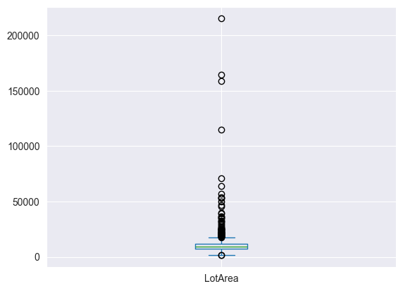

```python
df.LotArea.plot(kind='box')
```

Outlier #1 - LotArea - treatment

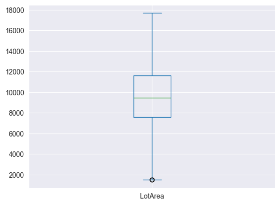

```python
df['LotArea'].clip(lower=np.int64(lot_area_lc), upper=np.int64(lot_area_uc), inplace=True)  # Casting to int64 for type compatibility
df.LotArea.plot(kind='box')
```

Outlier #2 - SalePrice

```python
sale_price_p0 = df.SalePrice.min()
sale_price_p100 = df.SalePrice.max()
sale_price_q1 = df.SalePrice.quantile(0.25)
sale_price_q2 = df.SalePrice.quantile(0.5)
sale_price_q3 = df.SalePrice.quantile(0.75)
sale_price_iqr = sale_price_q3 - sale_price_q1
```

```python
sale_price_lc = sale_price_q1 - 1.5 * sale_price_iqr  # lower cutoff
sale_price_uc = sale_price_q3 + 1.5 * sale_price_iqr  # upper cutoff
```

```python
sale_price_lc
```

```
3937.5
```

```python
sale_price_uc
```

```
340037.5
```

```python
print(f"PoolArea: p0 = {sale_price_p0}, p100 = {sale_price_p100}, lc = {sale_price_lc}, uc = {sale_price_uc}")
```

```
PoolArea: p0 = 34900, p100 = 755000, lc = 3937.5, uc = 340037.5
```

If lc < p0 → There are NO outliers on the bottom side If uc > p100 → There are NO outliers on the higher side

lc < p0, so there are no outliers on the bottom side (3937.5 < 34900). But uc < p100 (340037.5 < 755000), so there are outliers on the higher side. A visual representation of an outlier is provided by a box plot

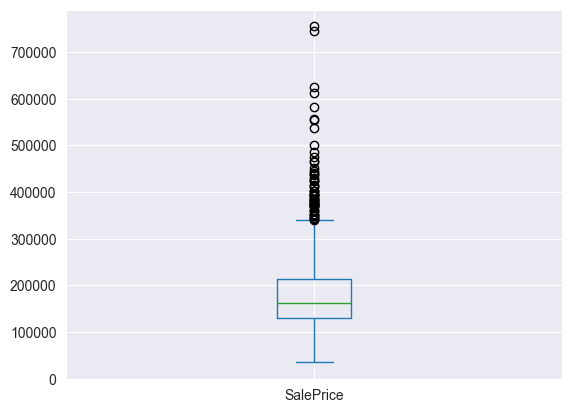

```python
df.SalePrice.plot(kind='box')
```

Outlier #2 - SalePrice - treatment

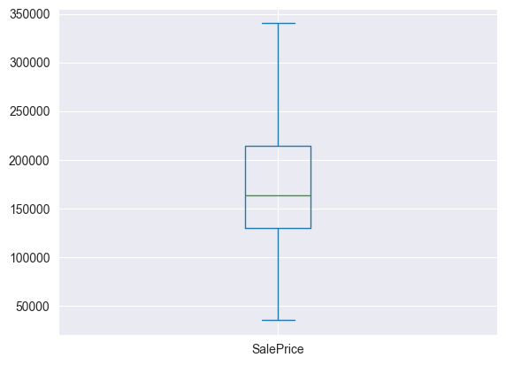

```python
df.SalePrice.clip(upper=np.int64(sale_price_uc), inplace=True)  # Casting to int64 for type compatibility
df.SalePrice.plot(kind='box')
```

Detecting missing values

```python
df.isna()
```

|  | Id | MSSubClass | MSZoning | LotFrontage | LotArea | Street | Alley | LotShape | LandContour | Utilities | ... | PoolArea | PoolQC | Fence | MiscFeature | MiscVal | MoSold | YrSold | SaleType | SaleCondition | SalePrice |
| --- | --- | --- | --- | --- | --- | --- | --- | --- | --- | --- | --- | --- | --- | --- | --- | --- | --- | --- | --- | --- | --- |
| 0 | False | False | False | False | False | False | True | False | False | False | ... | False | True | True | True | False | False | False | False | False | False |
| 1 | False | False | False | False | False | False | True | False | False | False | ... | False | True | True | True | False | False | False | False | False | False |
| 2 | False | False | False | False | False | False | True | False | False | False | ... | False | True | True | True | False | False | False | False | False | False |
| 3 | False | False | False | False | False | False | True | False | False | False | ... | False | True | True | True | False | False | False | False | False | False |
| 4 | False | False | False | False | False | False | True | False | False | False | ... | False | True | True | True | False | False | False | False | False | False |
| ... | ... | ... | ... | ... | ... | ... | ... | ... | ... | ... | ... | ... | ... | ... | ... | ... | ... | ... | ... | ... | ... |
| 1455 | False | False | False | False | False | False | True | False | False | False | ... | False | True | True | True | False | False | False | False | False | False |
| 1456 | False | False | False | False | False | False | True | False | False | False | ... | False | True | False | True | False | False | False | False | False | False |
| 1457 | False | False | False | False | False | False | True | False | False | False | ... | False | True | False | False | False | False | False | False | False | False |
| 1458 | False | False | False | False | False | False | True | False | False | False | ... | False | True | True | True | False | False | False | False | False | False |
| 1459 | False | False | False | False | False | False | True | False | False | False | ... | False | True | True | True | False | False | False | False | False | False |

1460 rows × 81 columns

```python
df.isna().sum()/df.shape[0]
```

```
Id               0.000000
MSSubClass       0.000000
MSZoning         0.000000
LotFrontage      0.177397
LotArea          0.000000
                   ...
MoSold           0.000000
YrSold           0.000000
SaleType         0.000000
SaleCondition    0.000000
SalePrice        0.000000
Length: 81, dtype: float64
```

```python
missing_values_df = pd.DataFrame({
    'missing_percent': df.isna().sum() / df.shape[0],
    'data_type': df.dtypes
})

missing_values_df = missing_values_df[missing_values_df['missing_percent'] > 0]  # Only shows columns containing empty values
```

```python
missing_values_df
```

|  | missing_percent | data_type |
| --- | --- | --- |
| LotFrontage | 0.177397 | float64 |
| Alley | 0.937671 | object |
| MasVnrType | 0.597260 | object |
| MasVnrArea | 0.005479 | float64 |
| BsmtQual | 0.025342 | object |
| BsmtCond | 0.025342 | object |
| BsmtExposure | 0.026027 | object |
| BsmtFinType1 | 0.025342 | object |
| BsmtFinType2 | 0.026027 | object |
| Electrical | 0.000685 | object |
| FireplaceQu | 0.472603 | object |
| GarageType | 0.055479 | object |
| GarageYrBlt | 0.055479 | float64 |
| GarageFinish | 0.055479 | object |
| GarageQual | 0.055479 | object |
| GarageCond | 0.055479 | object |
| PoolQC | 0.995205 | object |
| Fence | 0.807534 | object |
| MiscFeature | 0.963014 | object |

Missing values treatment (if < 50%)

```python
# Returns future pandas warning (does not affect the code, the task executes normally)
df.LotFrontage.fillna(df.LotFrontage.mean(), inplace=True)       # ~18% missing
df.drop(columns='Alley', inplace=True)                           # ~94% missing
df.drop(columns='MasVnrType', inplace=True)                      # ~60% missing
df.MasVnrArea.fillna(df.MasVnrArea.mean(), inplace=True)      # ~01% missing
df.BsmtQual.fillna(df.BsmtQual.mode()[0], inplace=True)          # ~03% missing
df.BsmtCond.fillna(df.BsmtCond.mode()[0], inplace=True)          # ~03% missing
df.BsmtExposure.fillna(df.BsmtExposure.mode()[0], inplace=True)  # ~03% missing
df.BsmtFinType1.fillna(df.BsmtFinType1.mode()[0], inplace=True)  # ~03% missing
df.BsmtFinType2.fillna(df.BsmtFinType2.mode()[0], inplace=True)  # ~03% missing
df.Electrical.fillna(df.Electrical.mode()[0], inplace=True)      # ~0.1% missing
df.FireplaceQu.fillna(df.FireplaceQu.mode()[0], inplace=True)    # ~47% missing
df.GarageType.fillna(df.GarageType.mode()[0], inplace=True)      # ~6% missing
df.GarageYrBlt.fillna(df.GarageYrBlt.mean(), inplace=True)    # ~6% missing
df.GarageFinish.fillna(df.GarageFinish.mode()[0], inplace=True)  # ~6% missing
df.GarageQual.fillna(df.GarageQual.mode()[0], inplace=True)      # ~6% missing
df.GarageCond.fillna(df.GarageCond.mode()[0], inplace=True)      # ~6% missing
df.drop(columns='PoolQC', inplace=True)                          # ~100% missing
df.drop(columns='Fence', inplace=True)                           # ~81% missing
df.drop(columns='MiscFeature', inplace=True)                     # ~96% missing
```

[output not shown]

[output cut: 43 more lines]

[output not shown]

```python
df.isna().sum()
```

```
Id               0
MSSubClass       0
MSZoning         0
LotFrontage      0
LotArea          0
                ..
MoSold           0
YrSold           0
SaleType         0
SaleCondition    0
SalePrice        0
Length: 76, dtype: int64
```

```python
treated_values_df = df.isna().sum() / df.shape[0]
treated_values_df[treated_values_df > 0]  # Shows that no column contain missing values
```

```
Series([], dtype: float64)
```

```python
df.dtypes
```

```
Id                 int64
MSSubClass         int64
MSZoning          object
LotFrontage      float64
LotArea            int64
                  ...
MoSold             int64
YrSold             int64
SaleType          object
SaleCondition     object
SalePrice          int64
Length: 76, dtype: object
```

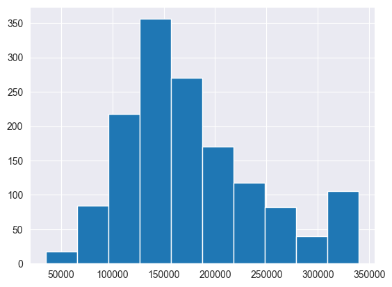

```python
df.SalePrice.hist()
plt.show()
```

or the same chart in the other way

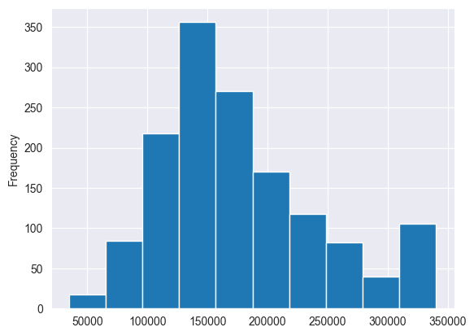

```python
df.SalePrice.plot(kind='hist', grid = True)
plt.show()
```

Using matplotlib

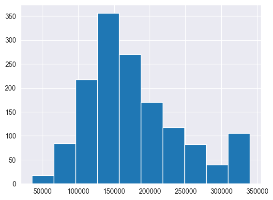

```python
plt.hist(df.SalePrice)
plt.grid(True)
plt.show()
```

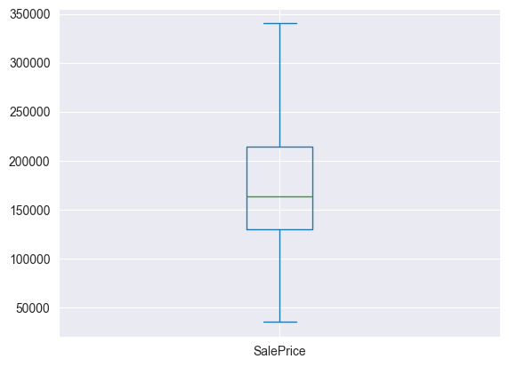

```python
df.SalePrice.plot(kind='box')
plt.show()
```

Using matplotlib

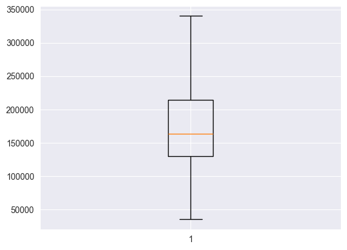

```python
plt.boxplot(df.SalePrice)
plt.show()
```

[figure not shown]

```python
df.groupby('CentralAir').Neighborhood.count().plot(kind='pie')
plt.show()
```

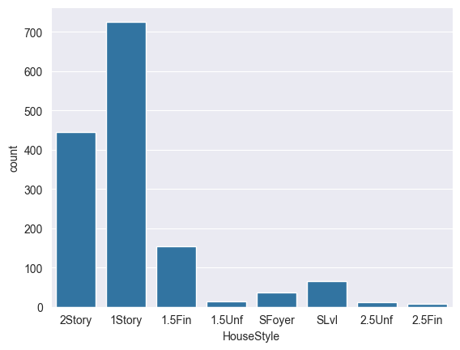

```python
sns.countplot(x=df["HouseStyle"])  # or sns.countplot(x=df.HouseStyle)
plt.show()
```

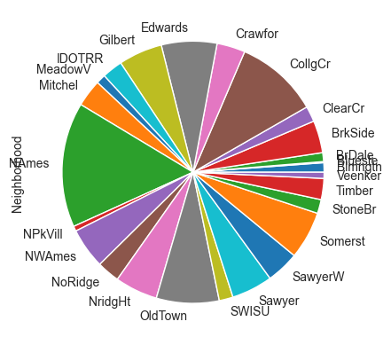

```python
df.groupby('Neighborhood').Neighborhood.count().plot(kind='pie')
plt.show()
```

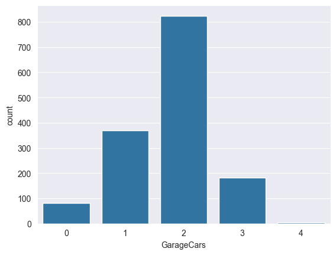

```python
sns.countplot(x=df["GarageCars"])  # or sns.countplot(x=df.GarageCars)
plt.show()
```

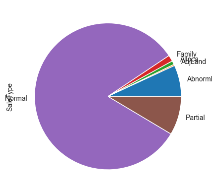

```python
df.groupby('SaleCondition').SaleType.count().plot(kind='pie')
plt.show()
```

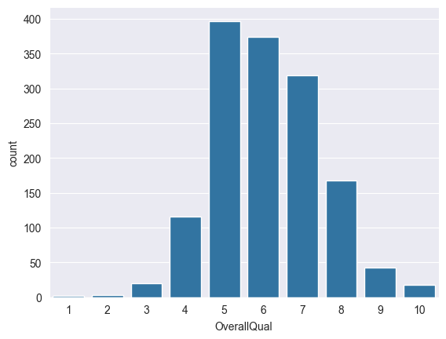

```python
sns.countplot(x=df["OverallQual"])  # or sns.countplot(x=df.OverallQual)
plt.show()
```

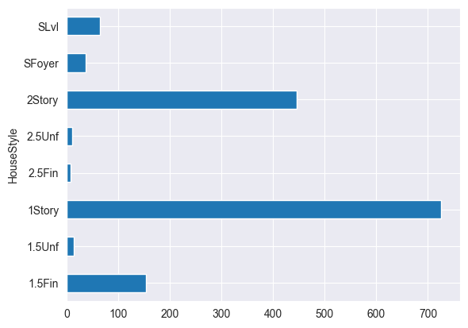

```python
df.groupby('HouseStyle').OverallQual.count().plot(kind='barh')
plt.show()
```

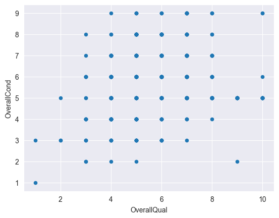

```python
df.plot(x='OverallQual', y='OverallCond', kind = 'scatter')
plt.show()
```

```python
garage_vars = ['GarageArea', 'GarageCars', 'YearBuilt', 'OverallQual', 'TotalBsmtSF', '1stFlrSF', 'GrLivArea', 'FullBath']
df[garage_vars].corr()
```

|  | GarageArea | GarageCars | YearBuilt | OverallQual | TotalBsmtSF | 1stFlrSF | GrLivArea | FullBath |
| --- | --- | --- | --- | --- | --- | --- | --- | --- |
| GarageArea | 1.000000 | 0.882475 | 0.478954 | 0.562022 | 0.486665 | 0.489782 | 0.468997 | 0.405656 |
| GarageCars | 0.882475 | 1.000000 | 0.537850 | 0.600671 | 0.434585 | 0.439317 | 0.467247 | 0.469672 |
| YearBuilt | 0.478954 | 0.537850 | 1.000000 | 0.572323 | 0.391452 | 0.281986 | 0.199010 | 0.468271 |
| OverallQual | 0.562022 | 0.600671 | 0.572323 | 1.000000 | 0.537808 | 0.476224 | 0.593007 | 0.550600 |
| TotalBsmtSF | 0.486665 | 0.434585 | 0.391452 | 0.537808 | 1.000000 | 0.819530 | 0.454868 | 0.323722 |
| 1stFlrSF | 0.489782 | 0.439317 | 0.281986 | 0.476224 | 0.819530 | 1.000000 | 0.566024 | 0.380637 |
| GrLivArea | 0.468997 | 0.467247 | 0.199010 | 0.593007 | 0.454868 | 0.566024 | 1.000000 | 0.630012 |
| FullBath | 0.405656 | 0.469672 | 0.468271 | 0.550600 | 0.323722 | 0.380637 | 0.630012 | 1.000000 |

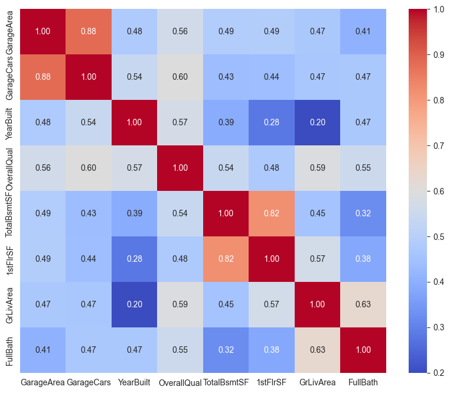

```python
plt.figure(figsize=(10,8))
sns.heatmap(df[garage_vars].corr(), annot=True, fmt=".2f", cmap='coolwarm')
plt.show()
```

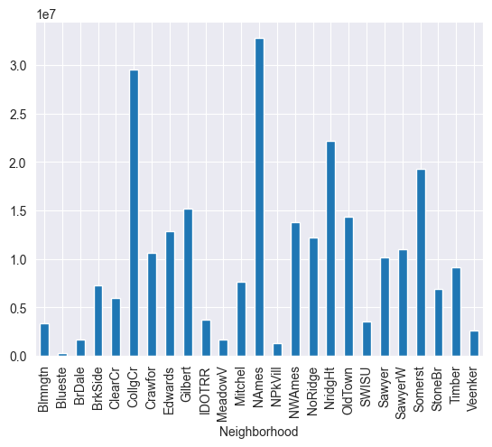

```python
df.groupby('Neighborhood')['SalePrice'].sum().plot(kind='bar')
plt.show()
```

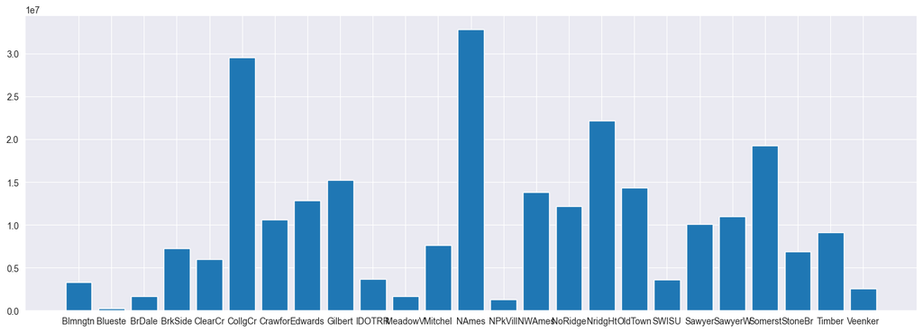

```python
summary = df.groupby('Neighborhood').SalePrice.sum()
plt.figure(figsize=(18,6))
plt.bar(x=summary.index , height=summary.values)
plt.show()
```

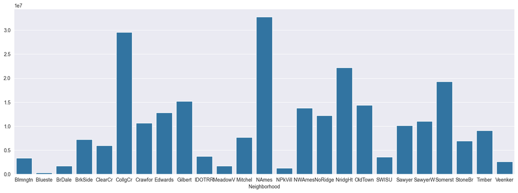

```python
plt.figure(figsize=(18,6))
sns.barplot(x=summary.index, y=summary.values)
plt.show()
```

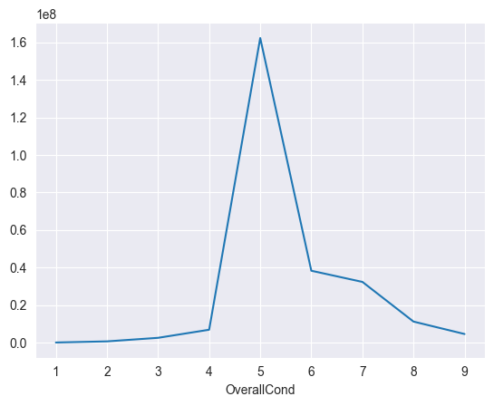

```python
df.groupby('OverallCond').SalePrice.sum().plot(kind='line')
plt.show()
```

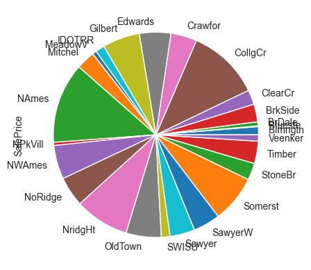

```python
df.groupby('Neighborhood').SalePrice.sum().plot(kind='pie')
plt.show()
```

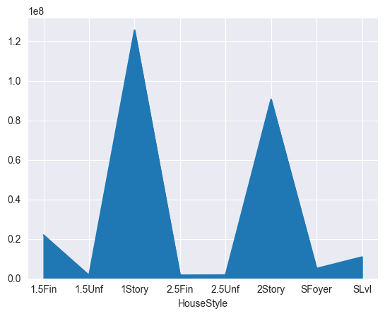

```python
df.groupby('HouseStyle').SalePrice.sum().plot(kind='area')
plt.show()
```

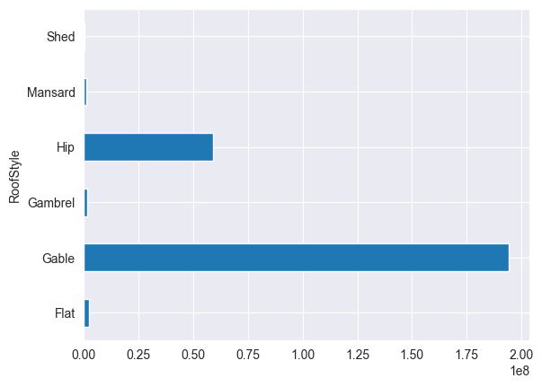

```python
df.groupby('RoofStyle').SalePrice.sum().plot(kind='barh')
plt.show()
```

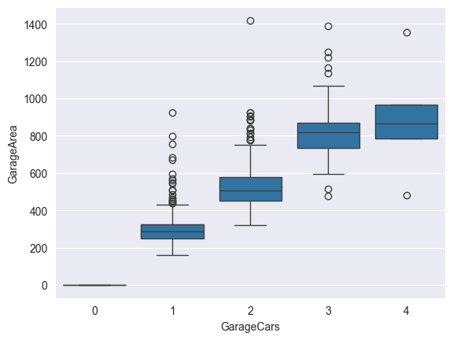

```python
sns.boxplot(x='GarageCars', y='GarageArea', data=df)
plt.show()
```

```python
pd.crosstab(df.Neighborhood, df.CentralAir)
```

| CentralAir Neighborhood | N | Y |
| --- | --- | --- |
| Blmngtn | 0 | 17 |
| Blueste | 0 | 2 |
| BrDale | 0 | 16 |
| BrkSide | 12 | 46 |
| ClearCr | 0 | 28 |
| CollgCr | 0 | 150 |
| Crawfor | 5 | 46 |
| Edwards | 18 | 82 |
| Gilbert | 1 | 78 |
| IDOTRR | 15 | 22 |
| MeadowV | 0 | 17 |
| Mitchel | 0 | 49 |
| NAmes | 8 | 217 |
| NPkVill | 0 | 9 |
| NWAmes | 0 | 73 |
| NoRidge | 0 | 41 |
| NridgHt | 0 | 77 |
| OldTown | 26 | 87 |
| SWISU | 7 | 18 |
| Sawyer | 2 | 72 |
| SawyerW | 1 | 58 |
| Somerst | 0 | 86 |
| StoneBr | 0 | 25 |
| Timber | 0 | 38 |
| Veenker | 0 | 11 |

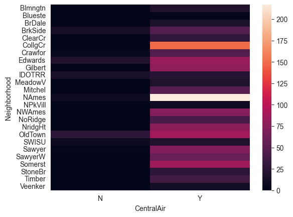

```python
sns.heatmap(pd.crosstab(df.Neighborhood, df.CentralAir))
plt.show()
```

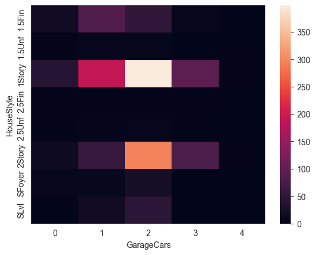

```python
sns.heatmap(pd.crosstab(df.HouseStyle, df.GarageCars))
plt.show()
```